# Transfer label CD8 T, NK and ILC cells (413)

Ramon Massoni-Badosa

mayo 2022

# 1 Introduction

In this notebook we will transfer the label and UMAP coordinates from the CD8 T cells, NK and ILC of the tonsil atlas to the cytotoxic cells of the MCL sample (case 413) using SLOcatoR.

# 2 Pre-processing

## 2.1 Load packages

```r
library(Seurat)
library(Signac)
library(SLOcatoR)
library(EnsDb.Hsapiens.v86)
library(ggpubr)
library(tidyverse)
library(pals)
library(here)
set.seed(173)
```

## 2.2 Define paths and parameters

```r
# Paths
path_to_query <-  here("MCL/results/R_objects/6.seurat_microenvironment_413.rds")
path_to_save1 <- here("MCL/results/R_objects/7.merged_CD8_T_ILC_NK_reference_query_413.rds")
path_to_save2 <- here("MCL/results/R_objects/7.seurat_CD8_T_ILC_NK_413_annotated.rds")


# Misc
label_var <- "annotation_paper"
batch_var <- "assay"


# Source key functions and variables
source(here("scRNA-seq/bin/utils_final_clusters.R"))
source(here("scRNA-seq/bin/utils_figure3.R"))
```

## 2.3 Read data

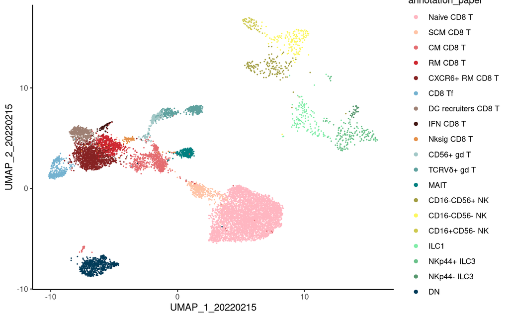

```r
cd8 <- readRDS(path_to_save_cd8)
ilc_nk <- readRDS(path_to_save_ilc_nk)
ilc_nk$UMAP_1_20220215 <- ilc_nk$UMAP_1_20220215 + 10
ilc_nk$UMAP_2_20220215 <- ilc_nk$UMAP_2_20220215 + 10
reference <- merge(x = cd8, y = ilc_nk)
reference$annotation_paper <- factor(
  reference$annotation_20220215,
  levels = names(colors_rna)
)
query <- readRDS(path_to_query)


# Plot
reference@meta.data %>%
  ggplot(aes(UMAP_1_20220215, UMAP_2_20220215, color = annotation_paper)) +
    geom_point(size = 0.1) +
    scale_color_manual(values = colors_rna, breaks = names(colors_rna)) +
    theme_classic() +
    guides(colour = guide_legend(override.aes = list(size = 1.5)))
```

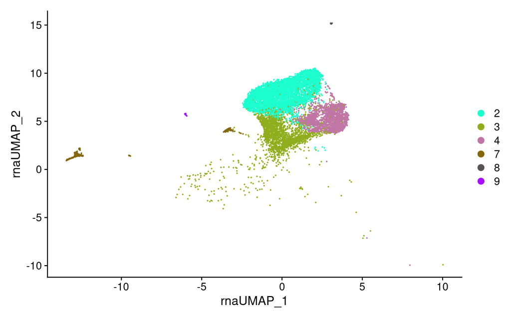

```r
DimPlot(query, cols = color_palette)
```

Since here we will focus on the RNA, let us remove the ATAC assay:

```r
# query[["ATAC"]] <- NULL
# cd8[["ADT"]] <- NULL
```

# 3 Transfer labels and UMAP coords

## 3.1 Subset query to keep only CD8 T cells, ILC and NK

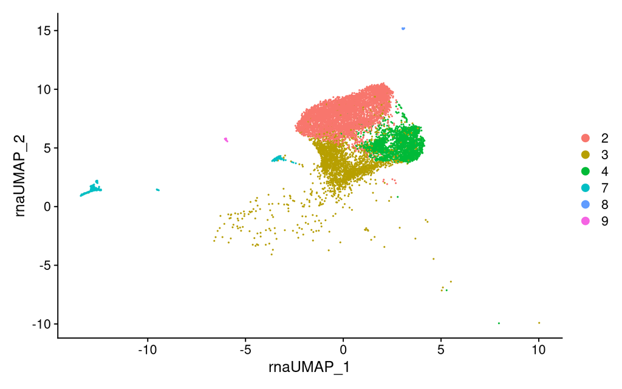

```r
DimPlot(query)
```

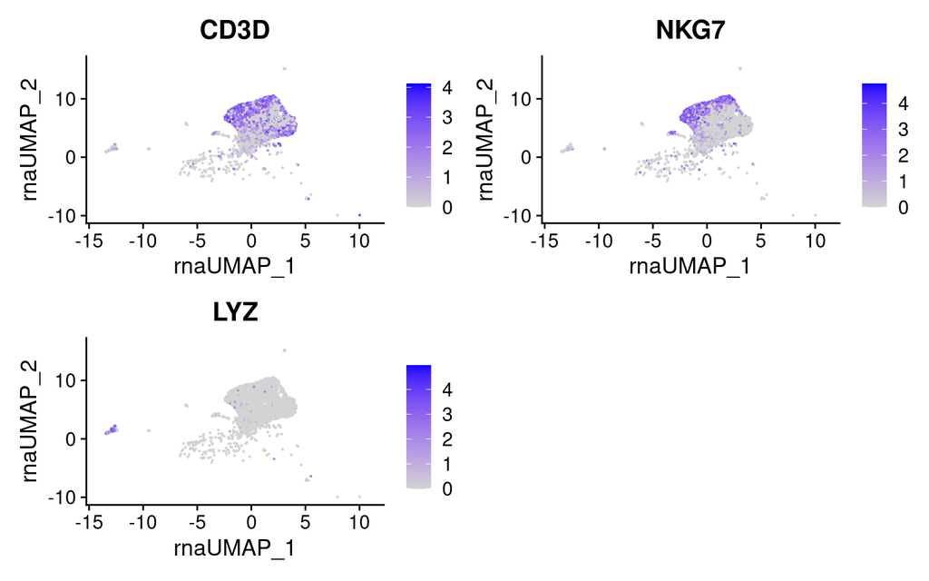

```r
FeaturePlot(query, c("CD3D", "NKG7", "LYZ"))
```

Cluster 7 is cleary myeloid and other non-lymphoid cells (CD3-LYZ+). Thus, let us subset to keep only clusters 2, 3 and 4 and recluster:

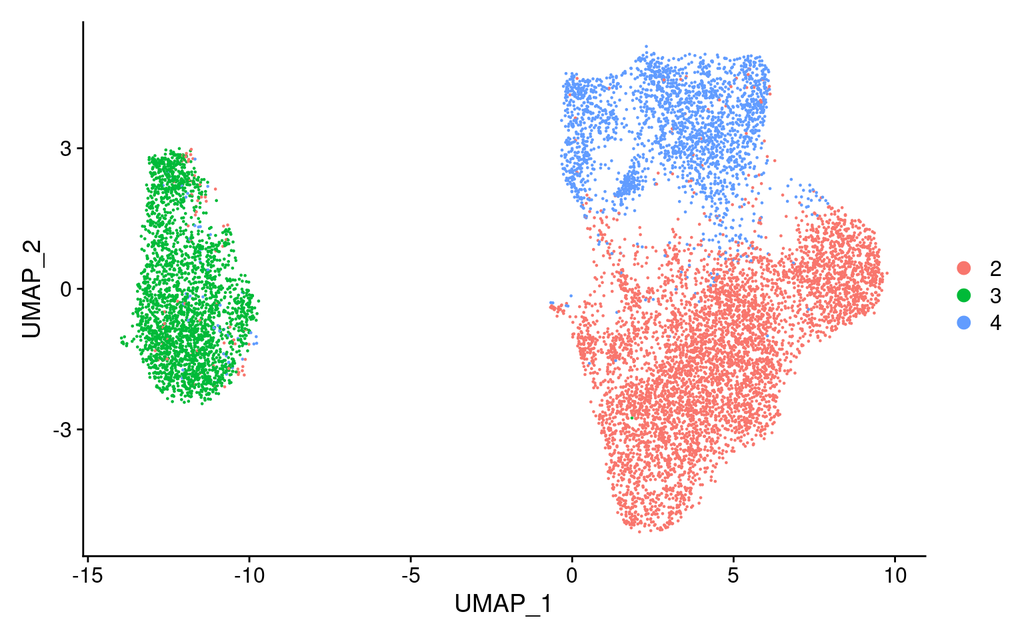

```r
query <- subset(query, idents = c("2", "3", "4"))
query <- query %>%
  FindVariableFeatures() %>%
  ScaleData() %>%
  RunPCA() %>%
  RunUMAP(dims = 1:20, reduction = "pca")
DimPlot(query, reduction = "umap")
```

Cluster with low resolution:

```r
query <- FindNeighbors(query, reduction = "pca", dims = 1:20)
query <- FindClusters(query, resolution = 0.1)
```

```
## Modularity Optimizer version 1.3.0 by Ludo Waltman and Nees Jan van Eck
##
## Number of nodes: 10343
## Number of edges: 372944
##
## Running Louvain algorithm...
## Maximum modularity in 10 random starts: 0.9545
## Number of communities: 3
## Elapsed time: 1 seconds
```

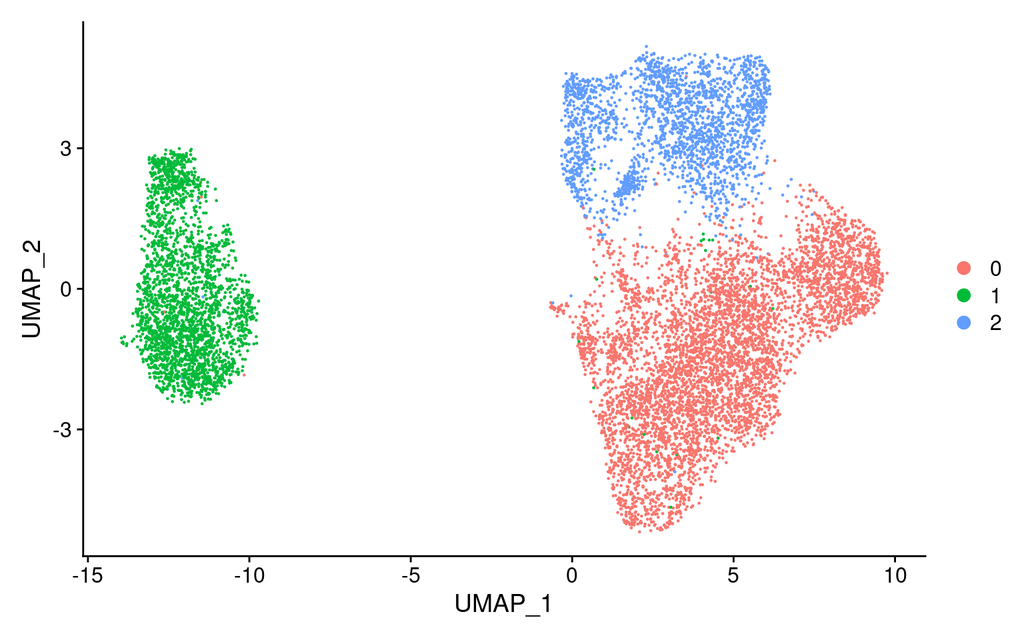

```r
DimPlot(query, reduction = "umap")
```

```r
# Find markers
markers_all <- FindAllMarkers(query, logfc.threshold = 0.5, only.pos = TRUE)
DT::datatable(markers_all)
```

|  | p_val | avg_log2FC | pct.1 | pct.2 | p_val_adj | cluster | gene |
| --- | --- | --- | --- | --- | --- | --- | --- |
| CCL5 | 0 | 2.46993251740621 | 0.723 | 0.282 | 0 | 0 | CCL5 |
| GZMK | 0 | 2.35841289301489 | 0.759 | 0.282 | 0 | 0 | GZMK |
| NKG7 | 0 | 2.16959618929136 | 0.583 | 0.23 | 0 | 0 | NKG7 |
| GZMA | 0 | 2.05572944931784 | 0.568 | 0.199 | 0 | 0 | GZMA |
| AGAP1 | 0 | 1.96632248458959 | 0.64 | 0.302 | 0 | 0 | AGAP1 |
| DTHD1 | 0 | 1.86305511977114 | 0.653 | 0.289 | 0 | 0 | DTHD1 |
| LYST | 0 | 1.83644843086384 | 0.845 | 0.567 | 0 | 0 | LYST |
| AOAH | 0 | 1.75994176529861 | 0.679 | 0.464 | 0 | 0 | AOAH |
| LINC01934 | 0 | 1.70954900793628 | 0.819 | 0.586 | 0 | 0 | LINC01934 |
| HLA-C | 0 | 1.04149803977996 | 0.85 | 0.794 | 0 | 0 | HLA-C |

[output cut: 787 more lines]

- Cluster 0: cytotoxic cells (CD8 T and/or NK and/or ILC)
- Cluster 1: doublets with B cells
- Cluster 2: CD4 T cells

Thus, we will conserve cluster 0

```r
query <- subset(query, idents = "0")
```

## 3.2 Merge

We will merge both objects, keeping only the variables in the metadata that are common for both:

```r
# Define new variables for label transfer
reference$type <- "reference"
query$type <- "query"
reference$batch <- reference@meta.data[[batch_var]]
reference$label <- reference@meta.data[[label_var]]
reference$annotation_probability <- NA
reference$UMAP1 <- reference$UMAP_1_20220215
reference$UMAP2 <- reference$UMAP_2_20220215
query$label <- NA
query$annotation_probability <- NA
query$batch <- "query"
query$UMAP1 <- NA
query$UMAP2 <- NA


# Find common columns and subset
common_cols <- intersect(
  colnames(reference@meta.data),
  colnames(query@meta.data)
)
reference@meta.data <- reference@meta.data[, common_cols]
query@meta.data <- query@meta.data[, common_cols]
```

Now we can merge:

```r
merged <- merge(x = reference, y = query)
```

## 3.3 Integrate

Let us start by finding the batch-specific highly variable features (HVG):

```r
shared_features <- find_assay_specific_features(merged, assay_var = "batch")
```

Integrate with Harmony:

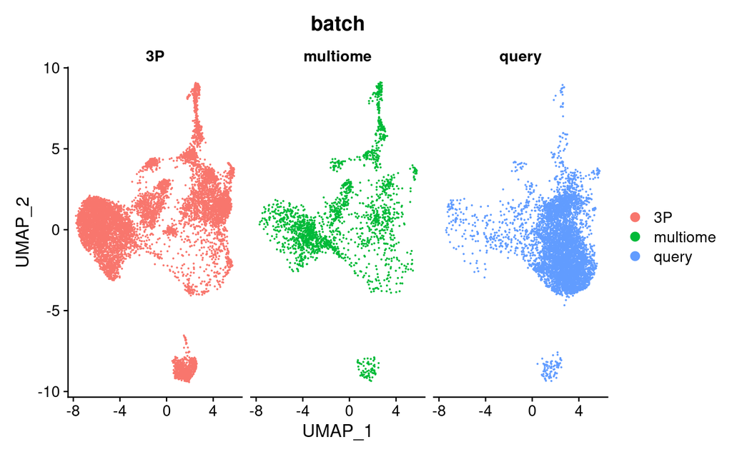

```r
# Integrate
merged <- integrate_assays(
  merged,
  assay_specific = TRUE,
  assay_var = "batch",
  shared_hvg = shared_features,
  n_dim = 30
)


# Visualize integration
merged <- RunUMAP(merged, dims = 1:30, reduction = "harmony")
DimPlot(merged, group.by = "batch", split.by = "batch")
```

## 3.4 Transfer labels

```r
# Define training and test sets
data_sets <- SLOcatoR::split_training_and_test_sets(
  merged,
  split_var = "type",
  referece_label = "reference",
  query_label = "query",
  reduction = "harmony",
  n_dims = 30
)


# Transfer label
annotation_query_df <- transfer_label(
  seurat_obj = merged,
  training_set = data_sets$training_set,
  test_set = data_sets$test_set,
  k = 10,
  response_var = "label"
)
```

## 3.5 Transfer UMAP coordinates

```r
umap_test_df <- transfer_umap_coords(
  seurat_obj = merged,
  training_set = data_sets$training_set,
  test_set = data_sets$test_set,
  umap1_var = "UMAP1",
  umap2_var = "UMAP2",
  k = 10
)
```

# 4 Plot

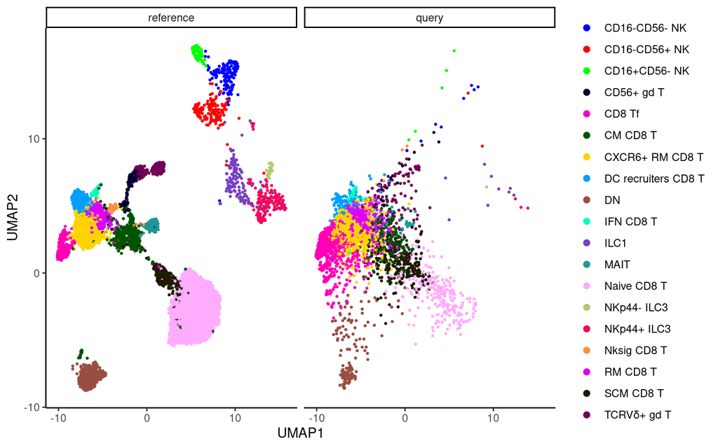

```r
merged$UMAP1[umap_test_df$query_cells] <- umap_test_df$UMAP1
merged$UMAP2[umap_test_df$query_cells] <- umap_test_df$UMAP2
merged$label[annotation_query_df$query_cells] <- annotation_query_df$annotation
merged$annotation_probability[annotation_query_df$query_cells] <- annotation_query_df$annotation_prob
(umap_gg <- merged@meta.data %>%
  mutate(type = factor(type, levels = c("reference", "query"))) %>%
  ggplot(aes(UMAP1, UMAP2, color = label)) +
    geom_point(size = 0.5) +
    facet_wrap(~type) +
    scale_color_manual(values = pals::glasbey()) +
    theme_classic() +
    theme(legend.title = element_blank()) +
    guides(color = guide_legend(override.aes = list(size = 2))))
```

Include annotations in query object:

```r
if (all(colnames(query) == annotation_query_df$query_cells)) {
  query$annotation_SLOcatoR <- annotation_query_df$annotation
  query$annotation_probability <- annotation_query_df$annotation_prob
}
if (all(colnames(query) == umap_test_df$query_cells)) {
  query$UMAP_1_SLOcatoR <- umap_test_df$UMAP1
  query$UMAP_2_SLOcatoR <- umap_test_df$UMAP2
}
query$label <- NULL
query$UMAP1 <- NULL
query$UMAP2 <- NULL
```

# 5 Save

```r
saveRDS(merged, path_to_save1)
saveRDS(query, path_to_save2)
# saveRDS(merged@meta.data, path_to_save_df)
```